# Regularization part 2

Kendra Wyant

2021-06-28

### Notes

Purpose: Demo of different regularization techniques using tidymodels in the context of a full workflow on the Ames data set.

### Setup

Paths

```r
path_data <- ""
```

Packages and Source

```r
# install.packages("cowplot")

library(cowplot)
library(tidyverse)
library(tidymodels)
library(kableExtra)
library(skimr)
library(naniar)
library(doParallel) # for parallel processing
library(mlbench) # where our dataset comes
library(vip)
library(Matrix)
library(glmnet)

options(tibble.print_max = Inf)
```

Setup Parallel Processing

```r
n_core <- detectCores(logical = FALSE)

cl <- makePSOCKcluster(n_core - 1)
registerDoParallel(cl)
```

Define function for plotting hyperparameters (Written by John Curtin)

```r
plot_hyperparameters <- function(tune_fit, hp1, hp2 = NULL, metric = NULL, log_hp1 = FALSE) {

  data <- collect_metrics(tune_fit)

  metric_scores <- data %>%
    filter(.metric == metric) %>%
    pull(mean)

  x1 <- data[[hp1]]
  if (log_hp1) x1 <- log(x1)

  if (is.null(hp2)) {
    ggplot(mapping = aes(x = x1, y = metric_scores)) +
      geom_line() +
      xlab(hp1) +
      ylab(metric)
  } else {
    x2 <- factor(data[[hp2]], ordered = TRUE)
    ggplot(mapping = aes(x = x1, y = metric_scores, group = x2, color = x2)) +
      geom_line() +
      xlab(hp1) +
      ylab(metric) +
      scale_color_discrete(name = hp2)
  }
}
```

### Load Data

```r
# install.packages("AmesHousing")
library(AmesHousing)

data_all <- ames_raw %>%
  janitor::clean_names() %>% # install.packages("janitor")
  glimpse()
```

```
## Rows: 2,930
## Columns: 82
## $ order           <int> 1, 2, 3, 4, 5, 6, 7, 8, 9, 10, 11, 12, 13, 14, 15, 16…
## $ pid             <chr> "0526301100", "0526350040", "0526351010", "0526353030…
## $ ms_sub_class    <chr> "020", "020", "020", "020", "060", "060", "120", "120…
## $ ms_zoning       <chr> "RL", "RH", "RL", "RL", "RL", "RL", "RL", "RL", "RL",…
## $ lot_frontage    <int> 141, 80, 81, 93, 74, 78, 41, 43, 39, 60, 75, NA, 63, …
## $ lot_area        <int> 31770, 11622, 14267, 11160, 13830, 9978, 4920, 5005, …
## $ street          <chr> "Pave", "Pave", "Pave", "Pave", "Pave", "Pave", "Pave…
## $ alley           <chr> NA, NA, NA, NA, NA, NA, NA, NA, NA, NA, NA, NA, NA, N…
## $ lot_shape       <chr> "IR1", "Reg", "IR1", "Reg", "IR1", "IR1", "Reg", "IR1…
## $ land_contour    <chr> "Lvl", "Lvl", "Lvl", "Lvl", "Lvl", "Lvl", "Lvl", "HLS…
## $ utilities       <chr> "AllPub", "AllPub", "AllPub", "AllPub", "AllPub", "Al…
## $ lot_config      <chr> "Corner", "Inside", "Corner", "Corner", "Inside", "In…
## $ land_slope      <chr> "Gtl", "Gtl", "Gtl", "Gtl", "Gtl", "Gtl", "Gtl", "Gtl…
```

[output cut: 69 more lines]

```r
?ames_raw


data_all <- data_all %>%
  select(-c(pid, order))
```

### Cleaning EDA (looks for errors that need to be cleaned)

Missing data

```r
data_all %>%
  miss_var_summary()
```

```
## # A tibble: 80 x 3
##    variable        n_miss pct_miss
##    <chr>            <int>    <dbl>
##  1 pool_qc           2917  99.6
##  2 misc_feature      2824  96.4
##  3 alley             2732  93.2
##  4 fence             2358  80.5
##  5 fireplace_qu      1422  48.5
##  6 lot_frontage       490  16.7
##  7 garage_yr_blt      159   5.43
##  8 garage_finish      159   5.43
##  9 garage_qual        159   5.43
## 10 garage_cond        159   5.43
## 11 garage_type        157   5.36
## 12 bsmt_exposure       83   2.83
```

[output cut: 68 more lines]

Numeric Predictors

```r
data_all %>%
  select(where(is.numeric)) %>%
  psych::describe() %>%
  select(n, min, max)
```

```
##                    n   min    max
## lot_frontage    2440    21    313
## lot_area        2930  1300 215245
## overall_qual    2930     1     10
## overall_cond    2930     1      9
## year_built      2930  1872   2010
## year_remod_add  2930  1950   2010
## mas_vnr_area    2907     0   1600
## bsmt_fin_sf_1   2929     0   5644
## bsmt_fin_sf_2   2929     0   1526
## bsmt_unf_sf     2929     0   2336
## total_bsmt_sf   2929     0   6110
## x1st_flr_sf     2930   334   5095
## x2nd_flr_sf     2930     0   2065
## low_qual_fin_sf 2930     0   1064
## gr_liv_area     2930   334   5642
## bsmt_full_bath  2928     0      3
## bsmt_half_bath  2928     0      2
## full_bath       2930     0      4
## half_bath       2930     0      2
## bedroom_abv_gr  2930     0      8
## kitchen_abv_gr  2930     0      3
## tot_rms_abv_grd 2930     2     15
## fireplaces      2930     0      4
## garage_yr_blt   2771  1895   2207
## garage_cars     2929     0      5
## garage_area     2929     0   1488
## wood_deck_sf    2930     0   1424
## open_porch_sf   2930     0    742
## enclosed_porch  2930     0   1012
## x3ssn_porch     2930     0    508
## screen_porch    2930     0    576
## pool_area       2930     0    800
## misc_val        2930     0  17000
## mo_sold         2930     1     12
## yr_sold         2930  2006   2010
## sale_price      2930 12789 755000
```

Categorical Predictors

```r
data_all %>%
  select(where(is.character)) %>%
  map(~ distinct(as_tibble(.)))
```

```
## $ms_sub_class
## # A tibble: 16 x 1
##    value
##    <chr>
##  1 020
##  2 060
##  3 120
##  4 050
##  5 085
##  6 160
##  7 080
##  8 030
##  9 090
## 10 190
## 11 045
## 12 070
## 13 075
## 14 040
## 15 180
## 16 150
##
## $ms_zoning
## # A tibble: 7 x 1
##   value
##   <chr>
## 1 RL
## 2 RH
## 3 FV
## 4 RM
## 5 C (all)
## 6 I (all)
## 7 A (agr)
##
## $street
## # A tibble: 2 x 1
##   value
##   <chr>
## 1 Pave
## 2 Grvl
##
```

[output cut: 464 more lines]

```
##  7 "Oth"
##  8 "ConLw"
##  9 "CWD"
## 10 "VWD"
##
## $sale_condition
## # A tibble: 6 x 1
##   value
##   <chr>
## 1 Normal
## 2 Partial
## 3 Family
## 4 Abnorml
## 5 Alloca
## 6 AdjLand
```

### Test/train split (also may have validation set)

```r
set.seed(20210606)
splits <- data_all %>%
  initial_split(prop = 3/4, strata = "sale_price")

data_trn <- analysis(splits) %>%
  glimpse()
```

```
## Rows: 2,199
## Columns: 80
## $ ms_sub_class    <chr> "020", "020", "060", "060", "120", "060", "060", "020…
## $ ms_zoning       <chr> "RL", "RL", "RL", "RL", "RL", "RL", "RL", "RL", "RL",…
## $ lot_frontage    <int> 141, 81, 74, 78, 41, 60, 75, NA, 63, 85, 47, 88, 140,…
## $ lot_area        <int> 31770, 14267, 13830, 9978, 4920, 7500, 10000, 7980, 8…
## $ street          <chr> "Pave", "Pave", "Pave", "Pave", "Pave", "Pave", "Pave…
## $ alley           <chr> NA, NA, NA, NA, NA, NA, NA, NA, NA, NA, NA, NA, NA, N…
## $ lot_shape       <chr> "IR1", "IR1", "IR1", "IR1", "Reg", "Reg", "IR1", "IR1…
## $ land_contour    <chr> "Lvl", "Lvl", "Lvl", "Lvl", "Lvl", "Lvl", "Lvl", "Lvl…
## $ utilities       <chr> "AllPub", "AllPub", "AllPub", "AllPub", "AllPub", "Al…
## $ lot_config      <chr> "Corner", "Corner", "Inside", "Inside", "Inside", "In…
## $ land_slope      <chr> "Gtl", "Gtl", "Gtl", "Gtl", "Gtl", "Gtl", "Gtl", "Gtl…
## $ neighborhood    <chr> "NAmes", "NAmes", "Gilbert", "Gilbert", "StoneBr", "G…
## $ condition_1     <chr> "Norm", "Norm", "Norm", "Norm", "Norm", "Norm", "Norm…
```

[output cut: 67 more lines]

```r
data_test <- assessment(splits) %>%
  glimpse()
```

```
## Rows: 731
## Columns: 80
## $ ms_sub_class    <chr> "020", "020", "120", "120", "120", "050", "020", "060…
## $ ms_zoning       <chr> "RH", "RL", "RL", "RL", "RL", "RL", "RL", "FV", "RM",…
## $ lot_frontage    <int> 80, 93, 43, 39, NA, 152, 85, NA, 21, 21, 24, 98, 90, …
## $ lot_area        <int> 11622, 11160, 5005, 5389, 6820, 12134, 13175, 7500, 1…
## $ street          <chr> "Pave", "Pave", "Pave", "Pave", "Pave", "Pave", "Pave…
## $ alley           <chr> NA, NA, NA, NA, NA, NA, NA, NA, NA, NA, NA, NA, NA, N…
## $ lot_shape       <chr> "Reg", "Reg", "IR1", "IR1", "IR1", "IR1", "Reg", "Reg…
## $ land_contour    <chr> "Lvl", "Lvl", "HLS", "Lvl", "Lvl", "Bnk", "Lvl", "Lvl…
## $ utilities       <chr> "AllPub", "AllPub", "AllPub", "AllPub", "AllPub", "Al…
## $ lot_config      <chr> "Inside", "Corner", "Inside", "Inside", "Corner", "In…
## $ land_slope      <chr> "Gtl", "Gtl", "Gtl", "Gtl", "Gtl", "Mod", "Gtl", "Gtl…
## $ neighborhood    <chr> "NAmes", "NAmes", "StoneBr", "StoneBr", "StoneBr", "G…
## $ condition_1     <chr> "Feedr", "Norm", "Norm", "Norm", "Norm", "Norm", "Nor…
```

[output cut: 67 more lines]

### Modeling EDA (To inform feature engineering)

Distributions

```r
data_trn %>%
  skim()
```

Data summary

| Name | Piped data |
| --- | --- |
| Number of rows | 2199 |
| Number of columns | 80 |
| _______________________ |  |
| Column type frequency: |  |
| character | 44 |
| numeric | 36 |
| ________________________ |  |
| Group variables | None |

**Variable type: character**

| skim_variable | n_missing | complete_rate | min | max | empty | n_unique | whitespace |
| --- | --- | --- | --- | --- | --- | --- | --- |
| ms_sub_class | 0 | 1.00 | 3 | 3 | 0 | 16 | 0 |
| ms_zoning | 0 | 1.00 | 2 | 7 | 0 | 7 | 0 |
| street | 0 | 1.00 | 4 | 4 | 0 | 2 | 0 |
| alley | 2046 | 0.07 | 4 | 4 | 0 | 2 | 0 |
| lot_shape | 0 | 1.00 | 3 | 3 | 0 | 4 | 0 |
| land_contour | 0 | 1.00 | 3 | 3 | 0 | 4 | 0 |
| utilities | 0 | 1.00 | 6 | 6 | 0 | 2 | 0 |
| lot_config | 0 | 1.00 | 3 | 7 | 0 | 5 | 0 |
| land_slope | 0 | 1.00 | 3 | 3 | 0 | 3 | 0 |
| neighborhood | 0 | 1.00 | 5 | 7 | 0 | 28 | 0 |
| condition_1 | 0 | 1.00 | 4 | 6 | 0 | 9 | 0 |
| condition_2 | 0 | 1.00 | 4 | 6 | 0 | 7 | 0 |
| bldg_type | 0 | 1.00 | 4 | 6 | 0 | 5 | 0 |
| house_style | 0 | 1.00 | 4 | 6 | 0 | 8 | 0 |
| roof_style | 0 | 1.00 | 3 | 7 | 0 | 6 | 0 |
| roof_matl | 0 | 1.00 | 4 | 7 | 0 | 8 | 0 |
| exterior_1st | 0 | 1.00 | 5 | 7 | 0 | 16 | 0 |
| exterior_2nd | 0 | 1.00 | 5 | 7 | 0 | 17 | 0 |
| mas_vnr_type | 18 | 0.99 | 4 | 7 | 0 | 5 | 0 |
| exter_qual | 0 | 1.00 | 2 | 2 | 0 | 4 | 0 |
| exter_cond | 0 | 1.00 | 2 | 2 | 0 | 5 | 0 |
| foundation | 0 | 1.00 | 4 | 6 | 0 | 6 | 0 |
| bsmt_qual | 64 | 0.97 | 2 | 2 | 0 | 5 | 0 |
| bsmt_cond | 64 | 0.97 | 2 | 2 | 0 | 5 | 0 |
| bsmt_exposure | 66 | 0.97 | 2 | 2 | 0 | 4 | 0 |
| bsmt_fin_type_1 | 64 | 0.97 | 3 | 3 | 0 | 6 | 0 |
| bsmt_fin_type_2 | 65 | 0.97 | 3 | 3 | 0 | 6 | 0 |
| heating | 0 | 1.00 | 4 | 5 | 0 | 6 | 0 |
| heating_qc | 0 | 1.00 | 2 | 2 | 0 | 5 | 0 |
| central_air | 0 | 1.00 | 1 | 1 | 0 | 2 | 0 |
| electrical | 1 | 1.00 | 3 | 5 | 0 | 5 | 0 |
| kitchen_qual | 0 | 1.00 | 2 | 2 | 0 | 5 | 0 |
| functional | 0 | 1.00 | 3 | 4 | 0 | 8 | 0 |
| fireplace_qu | 1075 | 0.51 | 2 | 2 | 0 | 5 | 0 |
| garage_type | 123 | 0.94 | 6 | 7 | 0 | 6 | 0 |
| garage_finish | 125 | 0.94 | 3 | 3 | 0 | 3 | 0 |
| garage_qual | 125 | 0.94 | 2 | 2 | 0 | 5 | 0 |
| garage_cond | 125 | 0.94 | 2 | 2 | 0 | 5 | 0 |
| paved_drive | 0 | 1.00 | 1 | 1 | 0 | 3 | 0 |
| pool_qc | 2188 | 0.01 | 2 | 2 | 0 | 4 | 0 |
| fence | 1763 | 0.20 | 4 | 5 | 0 | 4 | 0 |
| misc_feature | 2117 | 0.04 | 4 | 4 | 0 | 5 | 0 |
| sale_type | 0 | 1.00 | 3 | 5 | 0 | 10 | 0 |
| sale_condition | 0 | 1.00 | 6 | 7 | 0 | 6 | 0 |

**Variable type: numeric**

| skim_variable | n_missing | complete_rate | mean | sd | p0 | p25 | p50 | p75 | p100 | hist |
| --- | --- | --- | --- | --- | --- | --- | --- | --- | --- | --- |
| lot_frontage | 364 | 0.83 | 68.90 | 22.41 | 21 | 58.00 | 68.0 | 80.00 | 313 | ▇▃▁▁▁ |
| lot_area | 0 | 1.00 | 10128.62 | 6686.39 | 1300 | 7444.50 | 9477.0 | 11641.00 | 164660 | ▇▁▁▁▁ |
| overall_qual | 0 | 1.00 | 6.10 | 1.41 | 1 | 5.00 | 6.0 | 7.00 | 10 | ▁▁▇▅▁ |
| overall_cond | 0 | 1.00 | 5.57 | 1.12 | 1 | 5.00 | 5.0 | 6.00 | 9 | ▁▁▇▅▁ |
| year_built | 0 | 1.00 | 1971.05 | 30.45 | 1872 | 1953.00 | 1972.0 | 2000.00 | 2010 | ▁▂▃▆▇ |
| year_remod_add | 0 | 1.00 | 1984.34 | 20.92 | 1950 | 1965.00 | 1993.0 | 2004.00 | 2010 | ▅▂▂▃▇ |
| mas_vnr_area | 18 | 0.99 | 98.93 | 175.57 | 0 | 0.00 | 0.0 | 160.00 | 1600 | ▇▁▁▁▁ |
| bsmt_fin_sf_1 | 1 | 1.00 | 441.40 | 459.65 | 0 | 0.00 | 368.5 | 731.75 | 5644 | ▇▁▁▁▁ |
| bsmt_fin_sf_2 | 1 | 1.00 | 48.35 | 165.08 | 0 | 0.00 | 0.0 | 0.00 | 1526 | ▇▁▁▁▁ |
| bsmt_unf_sf | 1 | 1.00 | 561.01 | 438.55 | 0 | 220.00 | 465.0 | 808.00 | 2336 | ▇▅▂▁▁ |
| total_bsmt_sf | 1 | 1.00 | 1050.77 | 445.24 | 0 | 794.00 | 992.0 | 1294.50 | 6110 | ▇▃▁▁▁ |
| x1st_flr_sf | 0 | 1.00 | 1161.69 | 394.21 | 334 | 882.00 | 1088.0 | 1381.50 | 5095 | ▇▃▁▁▁ |
| x2nd_flr_sf | 0 | 1.00 | 337.51 | 433.82 | 0 | 0.00 | 0.0 | 708.00 | 2065 | ▇▃▂▁▁ |
| low_qual_fin_sf | 0 | 1.00 | 5.60 | 51.25 | 0 | 0.00 | 0.0 | 0.00 | 1064 | ▇▁▁▁▁ |
| gr_liv_area | 0 | 1.00 | 1504.80 | 518.78 | 334 | 1126.00 | 1442.0 | 1757.50 | 5642 | ▇▇▁▁▁ |
| bsmt_full_bath | 2 | 1.00 | 0.42 | 0.52 | 0 | 0.00 | 0.0 | 1.00 | 3 | ▇▆▁▁▁ |
| bsmt_half_bath | 2 | 1.00 | 0.06 | 0.25 | 0 | 0.00 | 0.0 | 0.00 | 2 | ▇▁▁▁▁ |
| full_bath | 0 | 1.00 | 1.56 | 0.55 | 0 | 1.00 | 2.0 | 2.00 | 4 | ▁▇▇▁▁ |
| half_bath | 0 | 1.00 | 0.38 | 0.50 | 0 | 0.00 | 0.0 | 1.00 | 2 | ▇▁▅▁▁ |
| bedroom_abv_gr | 0 | 1.00 | 2.86 | 0.83 | 0 | 2.00 | 3.0 | 3.00 | 8 | ▁▇▂▁▁ |
| kitchen_abv_gr | 0 | 1.00 | 1.04 | 0.20 | 0 | 1.00 | 1.0 | 1.00 | 3 | ▁▇▁▁▁ |
| tot_rms_abv_grd | 0 | 1.00 | 6.45 | 1.59 | 2 | 5.00 | 6.0 | 7.00 | 15 | ▁▇▂▁▁ |
| fireplaces | 0 | 1.00 | 0.59 | 0.65 | 0 | 0.00 | 1.0 | 1.00 | 4 | ▇▇▁▁▁ |
| garage_yr_blt | 125 | 0.94 | 1978.01 | 25.17 | 1896 | 1960.00 | 1979.0 | 2002.00 | 2010 | ▁▂▃▅▇ |
| garage_cars | 1 | 1.00 | 1.76 | 0.76 | 0 | 1.00 | 2.0 | 2.00 | 5 | ▅▇▂▁▁ |
| garage_area | 1 | 1.00 | 471.08 | 215.66 | 0 | 318.25 | 479.5 | 576.00 | 1488 | ▃▇▃▁▁ |
| wood_deck_sf | 0 | 1.00 | 94.17 | 128.22 | 0 | 0.00 | 0.0 | 168.00 | 1424 | ▇▁▁▁▁ |
| open_porch_sf | 0 | 1.00 | 48.33 | 70.11 | 0 | 0.00 | 27.0 | 70.00 | 742 | ▇▁▁▁▁ |
| enclosed_porch | 0 | 1.00 | 24.00 | 66.29 | 0 | 0.00 | 0.0 | 0.00 | 1012 | ▇▁▁▁▁ |
| x3ssn_porch | 0 | 1.00 | 2.16 | 23.03 | 0 | 0.00 | 0.0 | 0.00 | 508 | ▇▁▁▁▁ |
| screen_porch | 0 | 1.00 | 15.76 | 55.68 | 0 | 0.00 | 0.0 | 0.00 | 490 | ▇▁▁▁▁ |
| pool_area | 0 | 1.00 | 2.63 | 38.57 | 0 | 0.00 | 0.0 | 0.00 | 800 | ▇▁▁▁▁ |
| misc_val | 0 | 1.00 | 52.48 | 610.17 | 0 | 0.00 | 0.0 | 0.00 | 17000 | ▇▁▁▁▁ |
| mo_sold | 0 | 1.00 | 6.33 | 2.73 | 1 | 5.00 | 6.0 | 8.00 | 12 | ▃▆▇▃▃ |
| yr_sold | 0 | 1.00 | 2007.81 | 1.32 | 2006 | 2007.00 | 2008.0 | 2009.00 | 2010 | ▇▇▇▇▅ |
| sale_price | 0 | 1.00 | 180888.61 | 79811.54 | 13100 | 129500.00 | 160000.0 | 213500.00 | 755000 | ▇▇▁▁▁ |

Categorical variables

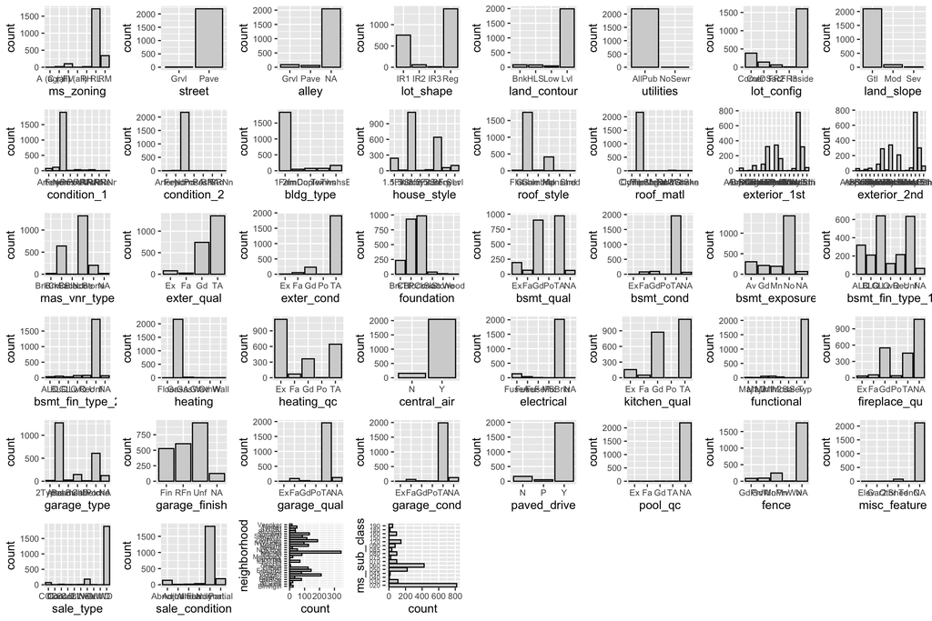

```r
plots_1 <- data_trn %>%
  select(where(is.character), -c(neighborhood, ms_sub_class)) %>%
  names() %>%
  map(., function(x){
    data_trn %>%
    ggplot(aes(x = .data[[x]])) +
    geom_bar(fill = "light grey", color = "black") +
    theme(axis.text.x = element_text(size = 8),
          axis.text.y = element_text(size = 8))
})

plots_2 <- data_trn %>%
  select(c(neighborhood, ms_sub_class)) %>%
  names() %>%
  map(., function(x){
    data_trn %>%
    ggplot(aes(x = .data[[x]])) +
    geom_bar(fill = "light grey", color = "black") +
    coord_flip() +
    theme(axis.text.y = element_text(size = 6),
          axis.text.x = element_text(size = 8))
})

plot_grid(plotlist = c(plots_1, plots_2), ncol= 8)
```

Numeric variables

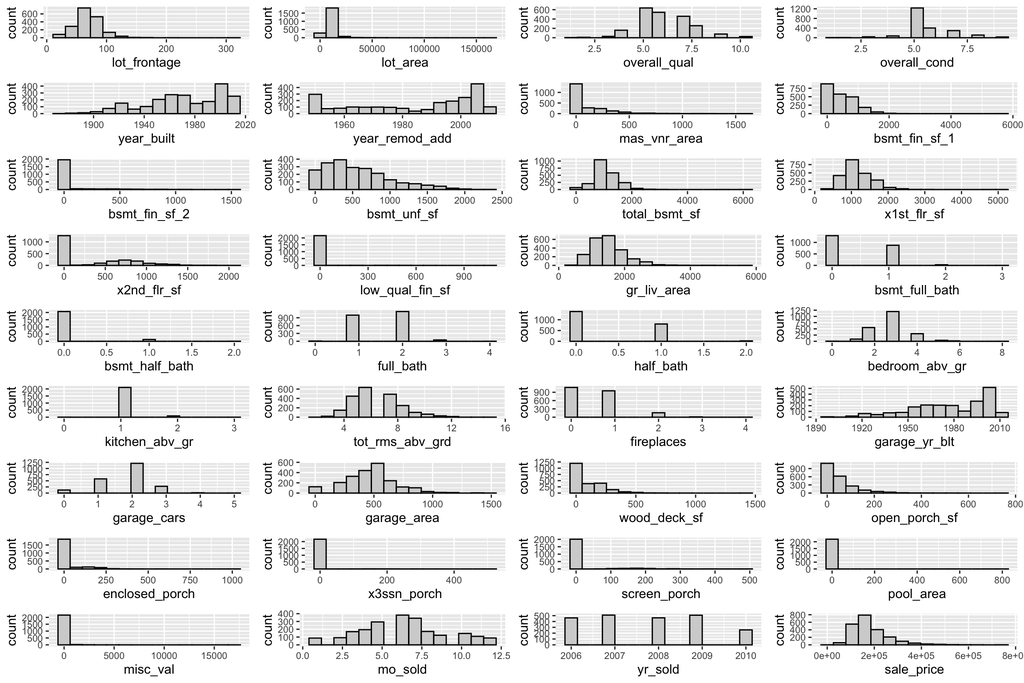

```r
plots_num <- data_trn %>%
  select(where(is.numeric)) %>%
  names() %>%
  map(., function(x){
    data_trn %>%
    ggplot(aes(x = .data[[x]])) +
    geom_histogram(bins = 15, fill = "light grey", color = "black") +
    theme(axis.text.x = element_text(size = 8),
          axis.text.y = element_text(size = 8))
})

plot_grid(plotlist = c(plots_num), ncol= 4)
```

Correlations

```r
data_trn %>%
  select(where(is.numeric)) %>%
  cor(use = "pairwise.complete.obs") %>%  # to accommodate missing data
  round(2)
```

```
##                 lot_frontage lot_area overall_qual overall_cond year_built
## lot_frontage            1.00     0.59         0.21        -0.10       0.12
## lot_area                0.59     1.00         0.10        -0.05       0.02
## overall_qual            0.21     0.10         1.00        -0.09       0.59
## overall_cond           -0.10    -0.05        -0.09         1.00      -0.37
## year_built              0.12     0.02         0.59        -0.37       1.00
## year_remod_add          0.09     0.01         0.57         0.05       0.61
## mas_vnr_area            0.24     0.13         0.42        -0.12       0.31
## bsmt_fin_sf_1           0.23     0.21         0.29        -0.06       0.28
## bsmt_fin_sf_2           0.04     0.06        -0.05         0.04      -0.03
## bsmt_unf_sf             0.13     0.03         0.26        -0.12       0.12
## total_bsmt_sf           0.37     0.26         0.53        -0.17       0.40
## x1st_flr_sf             0.47     0.37         0.47        -0.16       0.30
## x2nd_flr_sf             0.05     0.05         0.26         0.02       0.01
## low_qual_fin_sf         0.02     0.01        -0.04         0.01      -0.16
## gr_liv_area             0.40     0.33         0.57        -0.10       0.22
## bsmt_full_bath          0.09     0.12         0.17        -0.06       0.22
## bsmt_half_bath         -0.02     0.02        -0.03         0.07      -0.03
## full_bath               0.18     0.14         0.53        -0.21       0.46
## half_bath               0.07     0.06         0.27        -0.08       0.27
## bedroom_abv_gr          0.25     0.15         0.06         0.00      -0.08
## kitchen_abv_gr          0.01    -0.03        -0.16        -0.08      -0.13
## tot_rms_abv_grd         0.36     0.24         0.39        -0.09       0.10
## fireplaces              0.26     0.28         0.39        -0.02       0.16
## garage_yr_blt           0.08    -0.01         0.58        -0.32       0.83
## garage_cars             0.30     0.20         0.60        -0.17       0.52
## garage_area             0.36     0.25         0.57        -0.14       0.47
## wood_deck_sf            0.11     0.22         0.24         0.03       0.21
## open_porch_sf           0.19     0.13         0.30        -0.06       0.18
## enclosed_porch          0.04     0.04        -0.14         0.05      -0.37
## x3ssn_porch             0.04     0.02         0.01         0.05       0.01
## screen_porch            0.08     0.07         0.04         0.04      -0.05
## pool_area               0.22     0.14         0.03        -0.02       0.00
## misc_val                0.06     0.09         0.02         0.05      -0.01
## mo_sold                -0.01     0.00         0.05        -0.01       0.02
## yr_sold                 0.02    -0.03        -0.02         0.02       0.00
## sale_price              0.35     0.27         0.80        -0.10       0.55
##                 year_remod_add mas_vnr_area bsmt_fin_sf_1 bsmt_fin_sf_2
## lot_frontage              0.09         0.24          0.23          0.04
## lot_area                  0.01         0.13          0.21          0.06
```

[output cut: 278 more lines]

```
## tot_rms_abv_grd       0.50
## fireplaces            0.47
## garage_yr_blt         0.53
## garage_cars           0.64
## garage_area           0.64
## wood_deck_sf          0.32
## open_porch_sf         0.31
## enclosed_porch       -0.12
## x3ssn_porch           0.03
## screen_porch          0.11
## pool_area             0.07
## misc_val             -0.01
## mo_sold               0.04
## yr_sold              -0.02
## sale_price            1.00
```

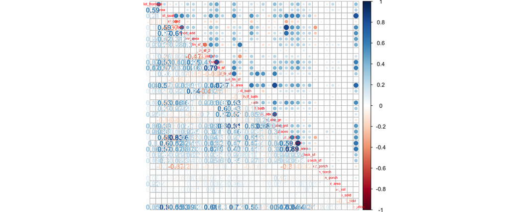

```r
data_trn %>%
  select(where(is.numeric)) %>%
  cor(use = "pairwise.complete.obs") %>%
  corrplot::corrplot.mixed(tl.cex = 0.5)
```

### Our Model

Outcome = continuous  
Statistical algorithm = linear regression  
Performance metric = RMSE

Tidymodels workflow:  
1. Create recipe  
2. Make features  
3. Model selection (in training data)  
4. Model evaluation (in test data)

### Recipe

Many different step functions for preprocessing data - https://recipes.tidymodels.org/reference/index.html

Simple linear regression recipe

```r
rec <- recipe(sale_price ~ ., data = data_trn) %>%
  # handle missing data
  step_rm(pool_qc, misc_feature, alley) %>%  # remove varibles with > 90% missing data
  # Note NA has a meaning for some variables
  step_mutate_at(c(fence, fireplace_qu, garage_finish, garage_qual, garage_cond, garage_type,
                     bsmt_exposure, bsmt_fin_type_2, bsmt_qual, bsmt_cond, bsmt_fin_type_1),
              fn = ~ ifelse(is.na(.), "None", .)) %>%
  step_medianimpute(all_numeric()) %>%
  step_modeimpute(all_nominal()) %>%
  # Dummy code categorical variables
  step_string2factor(all_nominal()) %>%
  step_dummy(all_nominal()) %>%
  step_normalize(all_predictors())
```

### Make features

Make feature matrices

```r
feat_trn <- rec %>%
  prep(training = data_trn, strings_as_factors = FALSE) %>%
  bake(new_data = data_trn) %>%
  glimpse()
```

```
## Rows: 2,199
## Columns: 277
## $ lot_frontage           <dbl> 3.52890357, 0.59838616, 0.25649246, 0.45186029…
## $ lot_area               <dbl> 3.236629688, 0.618925266, 0.553568651, -0.0225…
## $ overall_qual           <dbl> -0.06886603, -0.06886603, -0.77983506, -0.0688…
## $ overall_cond           <dbl> -0.5067757, 0.3847441, -0.5067757, 0.3847441, …
## $ year_built             <dbl> -0.362844797, -0.428526037, 0.852258150, 0.885…
## $ year_remod_add         <dbl> -1.1635127, -1.2591207, 0.6530384, 0.6530384, …
## $ mas_vnr_area           <dbl> 0.07929600, 0.05644853, -0.56043318, -0.446195…
## $ bsmt_fin_sf_1          <dbl> 0.43006201, 1.04806692, 0.76082520, 0.34954729…
## $ bsmt_fin_sf_2          <dbl> -0.2928366, -0.2928366, -0.2928366, -0.2928366…
## $ bsmt_unf_sf            <dbl> -0.27362256, -0.35344851, -0.96696789, -0.5404…
## $ total_bsmt_sf          <dbl> 0.065728755, 0.625107135, -0.275739171, -0.280…
## $ x1st_flr_sf            <dbl> 1.25392010, 0.42441760, -0.59280105, -0.597874…
## $ x2nd_flr_sf            <dbl> -0.7779960, -0.7779960, 0.8378946, 0.7848768, …
```

[output cut: 264 more lines]

```r
feat_test <- rec %>%
  prep(training = data_trn, strings_as_factors = FALSE) %>%
  bake(new_data = data_test)
```

```
## Warning: There are new levels in a factor: NA

## Warning: There are new levels in a factor: NA
```

new levels in a factor warning

```r
miss_var_summary(feat_test) %>%
  filter(n_miss > 0)
```

```
## # A tibble: 7 x 3
##   variable          n_miss pct_miss
##   <chr>              <int>    <dbl>
## 1 utilities_NoSewr       1    0.137
## 2 condition_2_Feedr      1    0.137
## 3 condition_2_Norm       1    0.137
## 4 condition_2_PosA       1    0.137
## 5 condition_2_PosN       1    0.137
## 6 condition_2_RRAn       1    0.137
## 7 condition_2_RRNn       1    0.137
```

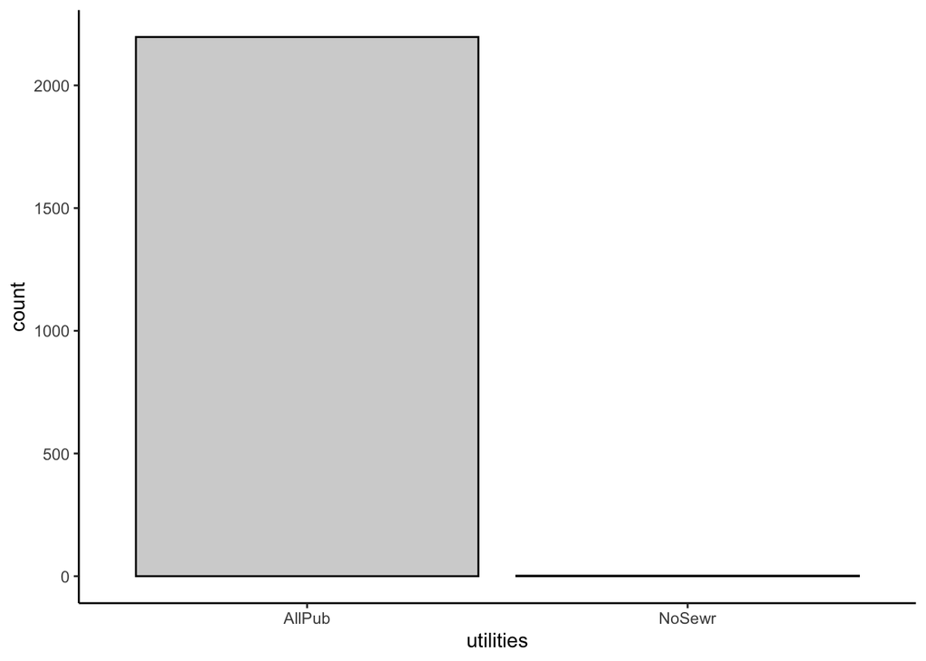

```r
# in our training data set we only have 2 out of 4 possible levels of the utilities var
data_trn %>%
  ggplot(aes(x = utilities)) +
  geom_bar(fill = "light grey", color = "black") +
  theme_classic()
```

Update recipe to accommodate new variable levels

```r
rec <- recipe(sale_price ~ ., data = data_trn) %>%
  # handle missing data
  step_rm(pool_qc, misc_feature, alley) %>%  # remove varibles with > 90% missing data
  # Note NA has a meaning for some variables
  step_mutate_at(c(fence, fireplace_qu, garage_finish, garage_qual, garage_cond, garage_type,
                     bsmt_exposure, bsmt_fin_type_2, bsmt_qual, bsmt_cond, bsmt_fin_type_1),
              fn = ~ ifelse(is.na(.), "None", .)) %>%
  step_medianimpute(all_numeric()) %>%
  step_modeimpute(all_nominal()) %>%
  # handle new factor levels
  step_novel(condition_2, utilities) %>%
  step_other(all_nominal()) %>%
  # Dummy code categorical variables
  step_string2factor(all_nominal()) %>%
  step_dummy(all_nominal()) %>%
  step_normalize(all_predictors())
```

feature matrices

```r
feat_trn <- rec %>%
  prep(training = data_trn, strings_as_factors = FALSE) %>%
  bake(new_data = data_trn)

feat_test <- rec %>%
  prep(training = data_trn, strings_as_factors = FALSE) %>%
  bake(new_data = data_test)
```

### Model Selection

Set up a tracking tibble to keep track of model performance

```r
track_rmse <- tibble(model = character(),
                     rmse_trn = numeric(),
                     n_features = numeric())
```

#### 1. No regularization

Fit model

```r
fit_linear <-
  linear_reg() %>%
  set_engine("lm") %>%
  fit(sale_price ~ ., data = feat_trn)
```

add to tracking tibble

```r
# get num features
linear_feat <- fit_linear %>%
  tidy() %>%
  filter(estimate != 0 & term != "(Intercept)") %>%
  nrow()

(track_rmse<- add_row(track_rmse,
                      model = "Linear regression w/no regularization",
                      rmse_trn = rmse_vec(truth = feat_trn$sale_price,
                                          estimate = predict(fit_linear, feat_trn)$.pred),
                      n_features = linear_feat))
```

```
## Warning in predict.lm(object = object$fit, newdata = new_data, type =
## "response"): prediction from a rank-deficient fit may be misleading
```

```
## # A tibble: 1 x 3
##   model                                 rmse_trn n_features
##   <chr>                                    <dbl>      <dbl>
## 1 Linear regression w/no regularization   27118.        135
```

Note the warning message - we have too many correlated predictors for a regular linear model!  
A model can’t be fit with perfect multicollinearity (cannot estimate parameters when we have redundant columns) so it drops a variable or variables and gives us this warning.

```r
fit_linear %>%
  tidy()
```

```
## # A tibble: 139 x 5
##     term                   estimate std.error statistic   p.value
##     <chr>                     <dbl>     <dbl>     <dbl>     <dbl>
##   1 (Intercept)            180889.       597.  303.      0.
##   2 lot_frontage            -1944.       906.   -2.15    3.20e- 2
##   3 lot_area                 1460.       833.    1.75    7.98e- 2
##   4 overall_qual            15703.      1260.   12.5     2.03e-34
##   5 overall_cond             5221.       863.    6.05    1.72e- 9
##   6 year_built               6214.      2107.    2.95    3.22e- 3
##   7 year_remod_add           1139.      1073.    1.06    2.89e- 1
##   8 mas_vnr_area             4039.       959.    4.21    2.63e- 5
##   9 bsmt_fin_sf_1          -35178.     88371.   -0.398   6.91e- 1
##  10 bsmt_fin_sf_2          -10476.     31760.   -0.330   7.42e- 1
##  11 bsmt_unf_sf            -36196.     84316.   -0.429   6.68e- 1
##  12 total_bsmt_sf           36965.     85427.    0.433   6.65e- 1
```

[output cut: 127 more lines]

This problem could be handled in the recipe with step_corr and step_nzv but lets move on to the next steps for now.

#### 2. Lasso regularization

Create splits  
We will use cross-validation instead of bootstrapping this time

```r
splits_kfold <- data_trn %>%
  # Note in your own data you likely will want to use repeated kfold
  vfold_cv(v = 10, repeats = 1, strata = "sale_price")
```

Set tune grid

```r
grid_penalty <- expand_grid(penalty = exp(seq(-4, 7, length.out = 500)))
```

Fit models

```r
fits_lasso <- linear_reg(penalty = tune(),
                           mixture = 1) %>%
  set_engine("glmnet") %>%
  tune_grid(preprocessor = rec,
            resamples = splits_kfold,
            grid = grid_penalty,
            metrics = metric_set(rmse))
```

Check hyperparameters

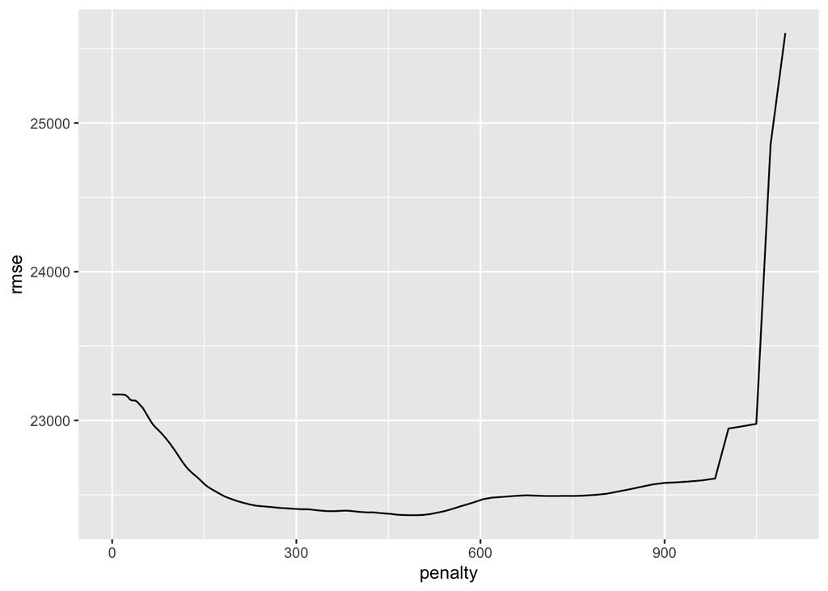

```r
plot_hyperparameters(fits_lasso, hp1 = "penalty", metric = "rmse")
```

Best penalty value

```r
show_best(fits_lasso)
```

```
## # A tibble: 5 x 7
##   penalty .metric .estimator   mean     n std_err .config
##     <dbl> <chr>   <chr>       <dbl> <int>   <dbl> <chr>
## 1    485. rmse    standard   22363.    10   1992. Preprocessor1_Model463
## 2    496. rmse    standard   22363.    10   1992. Preprocessor1_Model464
## 3    475. rmse    standard   22364.    10   1992. Preprocessor1_Model462
## 4    507. rmse    standard   22365.    10   1992. Preprocessor1_Model465
## 5    464. rmse    standard   22366.    10   1992. Preprocessor1_Model461
```

Fit best model to full training data

```r
fit_lasso <- linear_reg(penalty = select_best(fits_lasso)$penalty,
                        mixture = 1) %>%
  set_engine("glmnet") %>%
  fit(sale_price ~ ., data = feat_trn)
```

add to tracking tibble

```r
# get num features
lasso_feat <- fit_lasso %>%
  tidy() %>%
  filter(estimate != 0 & term != "(Intercept)") %>%
  nrow()

(track_rmse<- add_row(track_rmse,
                      model = "Lasso regression",
                      rmse_trn = rmse_vec(truth = feat_trn$sale_price,
                                          estimate = predict(fit_lasso, feat_trn)$.pred),
                      n_features = lasso_feat))
```

```
## # A tibble: 2 x 3
##   model                                 rmse_trn n_features
##   <chr>                                    <dbl>      <dbl>
## 1 Linear regression w/no regularization   27118.        135
## 2 Lasso regression                        27885.         93
```

Lets see how these 2 models compare in new data  
*Note again: this is only for educational purposes, you would not want to do anything with your test set yet*

```r
linear_test <- rmse_vec(truth = feat_test$sale_price,
                        estimate = predict(fit_linear, feat_test)$.pred)
lasso_test <- rmse_vec(truth = feat_test$sale_price,
                       estimate = predict(fit_lasso, feat_test)$.pred)

track_rmse %>%
  mutate(rmse_test = c(linear_test, lasso_test)) %>%
  select(1:2, 4, 3)
```

```
## # A tibble: 2 x 4
##   model                                 rmse_trn rmse_test n_features
##   <chr>                                    <dbl>     <dbl>      <dbl>
## 1 Linear regression w/no regularization   27118.    26667.        135
## 2 Lasso regression                        27885.    26387.         93
```

#### 3. Ridge regularization

Set tune grid

```r
grid_penalty <- expand_grid(penalty = exp(seq(-12, 13, length.out = 500)))
```

Fit models

```r
fits_ridge <- linear_reg(penalty = tune(),
                         mixture = 0) %>%
  set_engine("glmnet") %>%
  tune_grid(preprocessor = rec,
            resamples = splits_kfold,
            grid = grid_penalty,
            metrics = metric_set(rmse))
```

Check hyperparameters

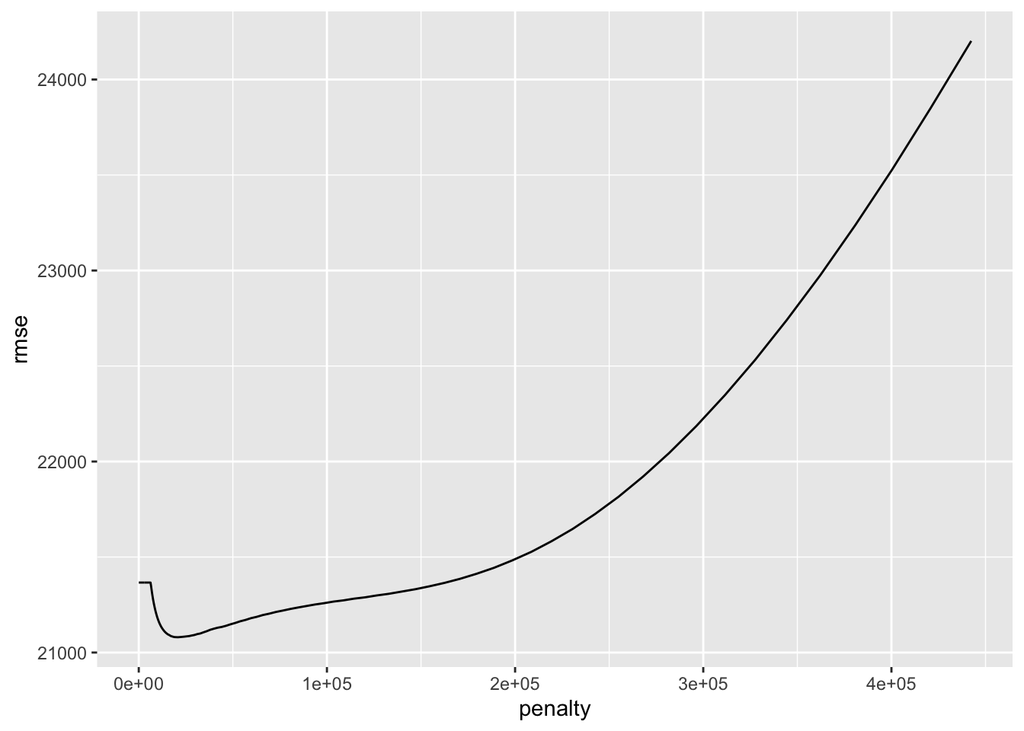

```r
plot_hyperparameters(fits_ridge, hp1 = "penalty", metric = "rmse")
```

Best penalty value

```r
show_best(fits_ridge)
```

```
## # A tibble: 5 x 7
##   penalty .metric .estimator   mean     n std_err .config
##     <dbl> <chr>   <chr>       <dbl> <int>   <dbl> <chr>
## 1  20825. rmse    standard   21080.    10   2222. Preprocessor1_Model439
## 2  19807. rmse    standard   21080.    10   2223. Preprocessor1_Model438
## 3  21894. rmse    standard   21081.    10   2222. Preprocessor1_Model440
## 4  18839. rmse    standard   21081.    10   2224. Preprocessor1_Model437
## 5  23019. rmse    standard   21082.    10   2221. Preprocessor1_Model441
```

Fit best model to full training data

```r
fit_ridge <- linear_reg(penalty = select_best(fits_ridge)$penalty,
                        mixture = 0) %>%
  set_engine("glmnet") %>%
  fit(sale_price ~ ., data = feat_trn)
```

add to tracking tibble

```r
# get num features
ridge_feat <- fit_ridge %>%
  tidy() %>%
  filter(estimate != 0 & term != "(Intercept)") %>%
  nrow()

(track_rmse<- add_row(track_rmse,
                      model = "Ridge regression",
                      rmse_trn = rmse_vec(truth = feat_trn$sale_price,
                                          estimate = predict(fit_ridge, feat_trn)$.pred),
                      n_features = ridge_feat))
```

```
## # A tibble: 3 x 3
##   model                                 rmse_trn n_features
##   <chr>                                    <dbl>      <dbl>
## 1 Linear regression w/no regularization   27118.        135
## 2 Lasso regression                        27885.         93
## 3 Ridge regression                        28755.        138
```

#### 4. Elasticnet regularization

Set tune grid

```r
grid_penalty <- expand_grid(penalty = exp(seq(-12, 10, length.out = 500)),
                            mixture = seq(0, 1, length.out = 11))
```

Fit models

```r
fits_en <- linear_reg(penalty = tune(),
                      mixture = tune()) %>%
  set_engine("glmnet") %>%
  tune_grid(preprocessor = rec,
            resamples = splits_kfold,
            grid = grid_penalty,
            metrics = metric_set(rmse))
```

Check hyperparameters

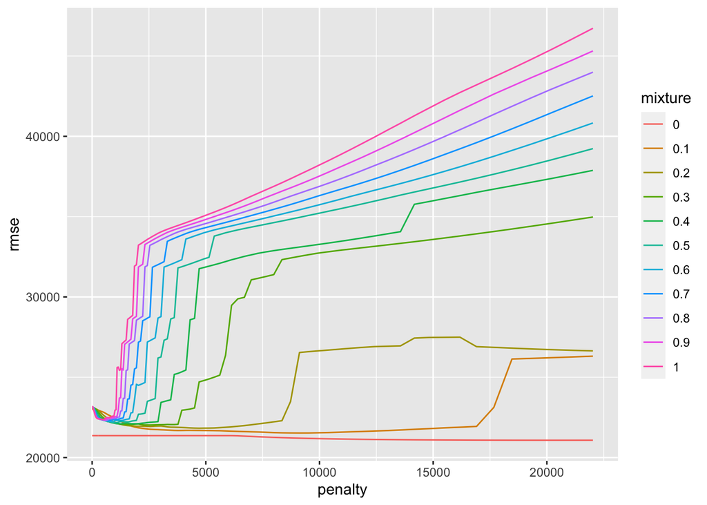

```r
plot_hyperparameters(fits_en, hp1 = "penalty", hp2 = "mixture", metric = "rmse")
```

Best penalty value

```r
show_best(fits_en)
```

```
## # A tibble: 5 x 8
##   penalty mixture .metric .estimator   mean     n std_err .config
##     <dbl>   <dbl> <chr>   <chr>       <dbl> <int>   <dbl> <chr>
## 1  20167.       0 rmse    standard   21080.    10   2223. Preprocessor1_Model04…
## 2  21076.       0 rmse    standard   21080.    10   2222. Preprocessor1_Model04…
## 3  19298.       0 rmse    standard   21081.    10   2223. Preprocessor1_Model04…
## 4  22026.       0 rmse    standard   21081.    10   2222. Preprocessor1_Model05…
## 5  18465.       0 rmse    standard   21082.    10   2224. Preprocessor1_Model04…
```

fit best model to full training data

```r
fit_en <- linear_reg(penalty = select_best(fits_en)$penalty,
                     mixture = select_best(fits_en)$mixture) %>%
  set_engine("glmnet") %>%
  fit(sale_price ~ ., data = feat_trn)
```

add to tracking tibble

```r
# get num features
en_feat <- fit_en %>%
  tidy() %>%
  filter(estimate != 0 & term != "(Intercept)") %>%
  nrow()

(track_rmse<- add_row(track_rmse,
                      model = "Elasticnet regression",
                      rmse_trn = rmse_vec(truth = feat_trn$sale_price,
                                          estimate = predict(fit_en, feat_trn)$.pred),
                      n_features = en_feat))
```

```
## # A tibble: 4 x 3
##   model                                 rmse_trn n_features
##   <chr>                                    <dbl>      <dbl>
## 1 Linear regression w/no regularization   27118.        135
## 2 Lasso regression                        27885.         93
## 3 Ridge regression                        28755.        138
## 4 Elasticnet regression                   28710.        138
```

### Model evaluation

```r
fit_best <- linear_reg(penalty = select_best(fits_lasso)$penalty,
                        mixture = 1) %>%
  set_engine("glmnet") %>%
  fit(sale_price ~ ., data = feat_trn)

rmse_vec(truth = feat_test$sale_price, estimate = predict(fit_best, feat_test)$.pred)
```

```
## [1] 26387.21
```

Get final model coefficients on full data set

```r
# feature matrix
feat_all <- rec %>%
  prep(training = data_all, strings_as_factors = FALSE) %>%
  bake(new_data = data_all)

# refit best model on entire data set
fit_best_full <- linear_reg(penalty = select_best(fits_lasso)$penalty,
                        mixture = 1) %>%
  set_engine("glmnet") %>%
  fit(sale_price ~ ., data = feat_all)

fit_best_full %>%
  tidy()
```

```
## # A tibble: 139 x 3
##     term                   estimate penalty
##     <chr>                     <dbl>   <dbl>
##   1 (Intercept)            180796.     485.
##   2 lot_frontage                0      485.
##   3 lot_area                 2522.     485.
##   4 overall_qual            16534.     485.
##   5 overall_cond             5082.     485.
##   6 year_built               6509.     485.
##   7 year_remod_add           1629.     485.
##   8 mas_vnr_area             4304.     485.
##   9 bsmt_fin_sf_1            3874.     485.
##  10 bsmt_fin_sf_2             789.     485.
##  11 bsmt_unf_sf                 0      485.
##  12 total_bsmt_sf            2930.     485.
```

[output cut: 127 more lines]

Feature important indices

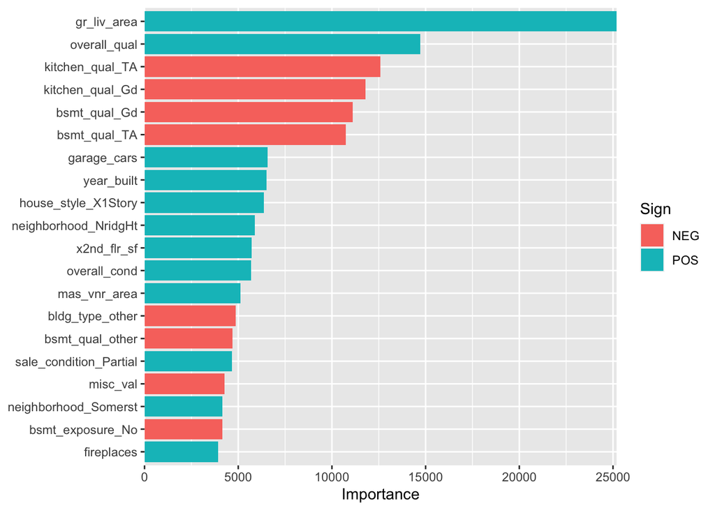

```r
fit_best_full$fit %>%
  vip::vi() %>%
  mutate(
    Importance = abs(Importance),
    Variable = fct_reorder(Variable, Importance)
  ) %>%
  head(20) %>%
  ggplot(aes(x = Importance, y = Variable, fill = Sign)) +
  geom_col() +
  scale_x_continuous(expand = c(0, 0)) +
  labs(y = NULL)
```